# Reproducible Research - Project 1: Activity Montioring Data Analysis

SrChip15

June 10, 2016

Let’s download the dataset from the given URL and load the dataset into our WD and after that remove the temp file that we no longer need

```r
# download the relevant dataset from an URL source and load it into workspace
URL <- "https://d396qusza40orc.cloudfront.net/repdata%2Fdata%2Factivity.zip"
temp <- tempfile()
download.file(URL, temp)
org.df <- read.csv(unz(temp, "activity.csv"), stringsAsFactors = FALSE)
unlink(temp)
```

Now that the dataset has been loaded, let’s get some statistics on the dataset to get an overview of the dataset

```r
# explore dataset
dim(org.df)
```

```
## [1] 17568     3
```

```r
summary(org.df)
```

```
##      steps            date              interval
##  Min.   :  0.00   Length:17568       Min.   :   0.0
##  1st Qu.:  0.00   Class :character   1st Qu.: 588.8
##  Median :  0.00   Mode  :character   Median :1177.5
##  Mean   : 37.38                      Mean   :1177.5
##  3rd Qu.: 12.00                      3rd Qu.:1766.2
##  Max.   :806.00                      Max.   :2355.0
##  NA's   :2304
```

```r
str(org.df)
```

```
## 'data.frame':    17568 obs. of  3 variables:
##  $ steps   : int  NA NA NA NA NA NA NA NA NA NA ...
##  $ date    : chr  "2012-10-01" "2012-10-01" "2012-10-01" "2012-10-01" ...
##  $ interval: int  0 5 10 15 20 25 30 35 40 45 ...
```

Right off the bat, we observe that the “date” variable is interpreted as a character datatype. Let’s go ahead and convert it into the appropriate date format

```r
# convert date from char to date
org.df$date <- as.Date(org.df$date)
str(org.df)
```

```
## 'data.frame':    17568 obs. of  3 variables:
##  $ steps   : int  NA NA NA NA NA NA NA NA NA NA ...
##  $ date    : Date, format: "2012-10-01" "2012-10-01" ...
##  $ interval: int  0 5 10 15 20 25 30 35 40 45 ...
```

The “str” call now confirms that the said variable is in the appropriate date format

Now, let’s aggregate the dataset to get the total number of steps taken in a day

```r
#  aggregate number of steps on date
agg_date.df <- setNames(aggregate(org.df$steps ~ org.df$date, data = org.df, FUN = sum), c("Date","Steps"))
head(agg_date.df)
```

```
##         Date Steps
## 1 2012-10-02   126
## 2 2012-10-03 11352
## 3 2012-10-04 12116
## 4 2012-10-05 13294
## 5 2012-10-06 15420
## 6 2012-10-07 11015
```

As we can observe from the “head” call, now we ONLY see UNIQUE dates, assuring that the steps have been aggregated over unique dates

For the first part of the assignment, let’s graph a histogram of the total number of steps taken each day and also report the mean and median of the total number of steps taken per day

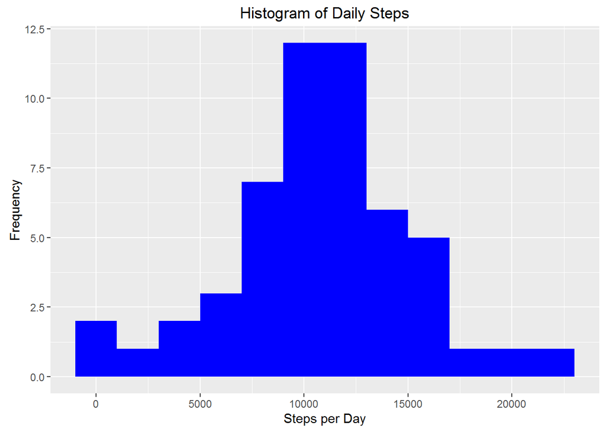

```r
# load library and make a histogram (gg)
library(ggplot2)
ggplot(agg_date.df, aes(Steps)) +
        geom_histogram(binwidth = 2000, fill = "blue") +
        labs(title = "Histogram of Daily Steps", x = "Steps per Day", y = "Frequency")
```

```r
# mean and median
mean_org <- mean(agg_date.df$Steps)
median_org <- median(agg_date.df$Steps)
print(mean_org)
```

```
## [1] 10766.19
```

```r
print(median_org)
```

```
## [1] 10765
```

The mean and the median differ by 1.19 steps, not significantly different from each other implying that the datapoints are failry equally distributed

Moving on to the next question in the assignment - Average Daily Activity Pattern. For this purpose, we would be averaging the total number of steps taken in a day over the 5-minute intervals for all the days present in the dataset.

Further, we report the interval with the maximum number of steps

```r
# averaging the number of steps over 5-minute intervals
agg_int.df <- setNames(aggregate(org.df$steps ~ org.df$interval, data = org.df, FUN = mean), c("Interval","Steps"))

# report the interval with the highest mean number of steps
max_int_avg <- agg_int.df[which.max(agg_int.df$Steps),]
print(max_int_avg)
```

```
##     Interval    Steps
## 104      835 206.1698
```

Let’s visualize the same by way of a time series plot

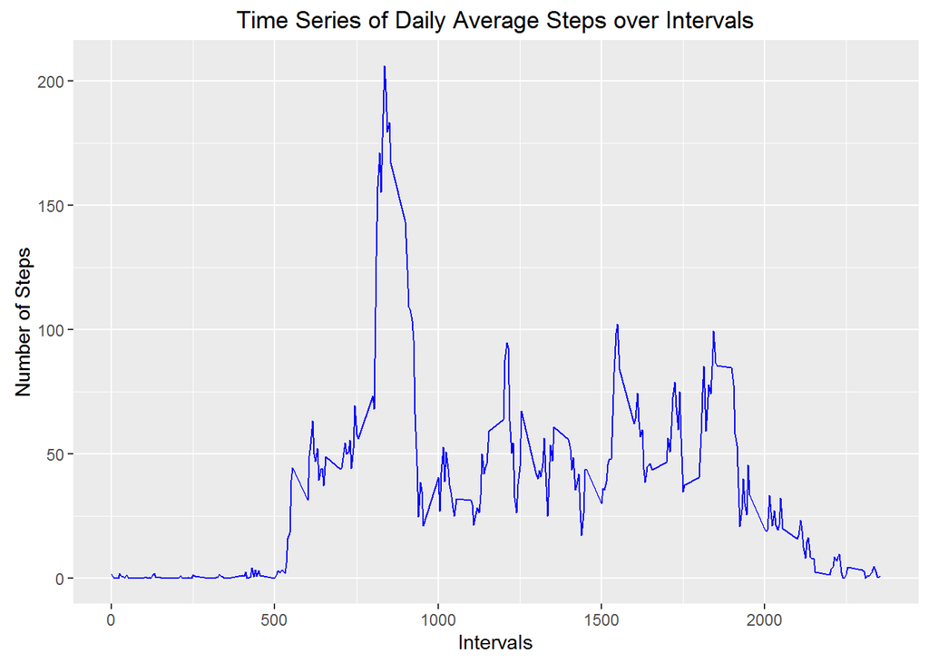

```r
# time series plot of average steps across intervals
ggplot(agg_int.df, aes(x = Interval, y = Steps)) +
        geom_line(color = "blue") +
        labs(title = "Time Series of Daily Average Steps over Intervals", x = "Intervals", y = "Number of Steps")
```

Missing values! Like any real dataset, the current dataset is also riddled with missing values. So, let’s analyze the number of missing value cases and also the corresponding variables

```r
# number of missing values
missing_val <- sapply(org.df, function(x) sum(is.na(x)))
print(missing_val)
```

```
##    steps     date interval
##     2304        0        0
```

Approximately, missing value cases constitute 13.11% of the dataset and this is entirely from the “steps” variable in the dataset

This is a fairly significant proportion of the dataset. So, a simple mean value imputation is enforced in the dataset

```r
# copy original dataset
imp.df <- org.df

# impute missing values with the mean
imp.df$steps[is.na(imp.df$steps)] <- mean(imp.df$steps, na.rm = TRUE)
str(imp.df)
```

```
## 'data.frame':    17568 obs. of  3 variables:
##  $ steps   : num  37.4 37.4 37.4 37.4 37.4 ...
##  $ date    : Date, format: "2012-10-01" "2012-10-01" ...
##  $ interval: int  0 5 10 15 20 25 30 35 40 45 ...
```

Now let’s again aggregate the number of steps over unique dates and report the mean and median of the same

```r
# aggregate the imputed data set to get the total number of steps taken daily
agg_date_imp.df <- setNames(aggregate(imp.df$steps ~ imp.df$date, data = imp.df, FUN = sum), c("Date","Steps"))

# mean and median of imputed dataset
mean_imp <- mean(agg_date_imp.df$Steps)
median_imp <- median(agg_date_imp.df$Steps)
print(mean_imp)
```

```
## [1] 10766.19
```

```r
print(median_imp)
```

```
## [1] 10766.19
```

Now the mean and the median have the same value. Without imputation, the mean and the median differed by 1.19 steps. So, in this case, since the original data (with missing values) is equally distributed, there is none to negligibel impact on the dataset. Factually, we are able to see that the mean and median are now equal

Visualizing the total number of steps after imputing for missing values

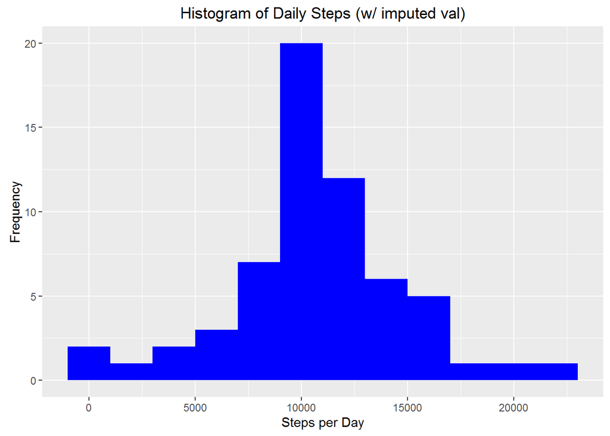

```r
# histogram of total number of steps taken each day (with imputed values)
ggplot(agg_date_imp.df, aes(Steps)) +
        geom_histogram(binwidth = 2000, fill = "blue") +
        labs(title = "Histogram of Daily Steps (w/ imputed val)", x = "Steps per Day", y = "Frequency")
```

Before we wrap up, let’s analyze the dataset for activity distributions from a weekday Vs. weekend standpoint. As a result, we would need to engineer a new feature, which I would title as “DayType”. Basically, this would be a 2-level factor variable, namely - Weekday or Weekend.

```r
# add DayType (weekend/weekday) feature into the imputed dataset
weekend <- c("Saturday","Sunday")
imp.df$DayType <- as.factor(ifelse(weekdays(imp.df$date) %in% weekend, "Weekend", "Weekday"))
head(imp.df)
```

```
##     steps       date interval DayType
## 1 37.3826 2012-10-01        0 Weekday
## 2 37.3826 2012-10-01        5 Weekday
## 3 37.3826 2012-10-01       10 Weekday
## 4 37.3826 2012-10-01       15 Weekday
## 5 37.3826 2012-10-01       20 Weekday
## 6 37.3826 2012-10-01       25 Weekday
```

```r
str(imp.df)
```

```
## 'data.frame':    17568 obs. of  4 variables:
##  $ steps   : num  37.4 37.4 37.4 37.4 37.4 ...
##  $ date    : Date, format: "2012-10-01" "2012-10-01" ...
##  $ interval: int  0 5 10 15 20 25 30 35 40 45 ...
##  $ DayType : Factor w/ 2 levels "Weekday","Weekend": 1 1 1 1 1 1 1 1 1 1 ...
```

Okay, now let’s average the number of steps taken in the imputed dataset over intervals for all the days

```r
# aggregate data points over intervals
agg_int_imp.df <- setNames(aggregate(imp.df$steps ~ imp.df$interval + imp.df$DayType, data = imp.df, FUN = mean), c("Interval","DayType", "Steps"))
head(agg_int_imp.df)
```

```
##   Interval DayType    Steps
## 1        0 Weekday 7.006569
## 2        5 Weekday 5.384347
## 3       10 Weekday 5.139902
## 4       15 Weekday 5.162124
## 5       20 Weekday 5.073235
## 6       25 Weekday 6.295458
```

```r
tail(agg_int_imp.df)
```

```
##     Interval DayType     Steps
## 571     2330 Weekend  5.735325
## 572     2335 Weekend 15.672825
## 573     2340 Weekend 10.547825
## 574     2345 Weekend  6.297825
## 575     2350 Weekend  4.672825
## 576     2355 Weekend  4.672825
```

Finally, let’s visualize the mean number of steps over different intervals in a weekday Vs. weekend perspective to observe a pattern (if any)

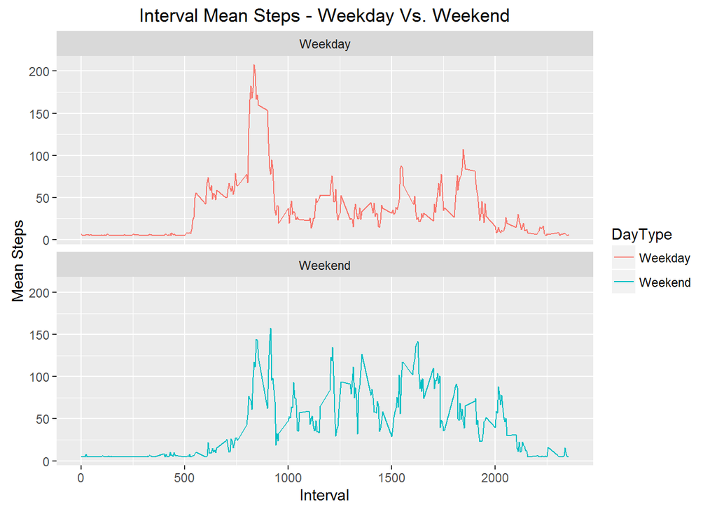

```r
# time series panel plot for Interval Mean Steps - Weekday Vs. Weekend
ggplot(agg_int_imp.df, aes(x = Interval, y = Steps, color = DayType)) +
        geom_line() +
        facet_wrap(~DayType, ncol = 1, nrow = 2) +
        labs(title = "Interval Mean Steps - Weekday Vs. Weekend", x = "Interval", y = "Mean Steps")
```